# Figures for MS: Spatiotemporal variation in mountain stream metabolism and nitrogen cycling across contrasting flow regimes

Kelly Loria

2025-02-04

## Research Questions:

1. How does mountain stream productivity vary based on nitrogen availability, light exposure, and antecedent flow conditions?
2. Is variance in nitrogen uptake (either as ammonium or nitrate) more related to biological (GPP, ER, biomass or chl-a), physical processes (flow and water temperature), or ambient nutrient and organic matter supplies?

## Question 1:

1. How does mountain stream productivity vary based on nitrogen availability, light exposure, and antecedent flow conditions?

##### Figures 2 & 3.

### Figure 2: Metabolism Time sieries

- Need to describe the magnitude of GPP and ER across all sites
- Need to describe the maginitude of change in GPP and ER across each site 2021-2024.

Where GPP is in green, ER is in purple, NEP is in black dataframe: `metab_dat`

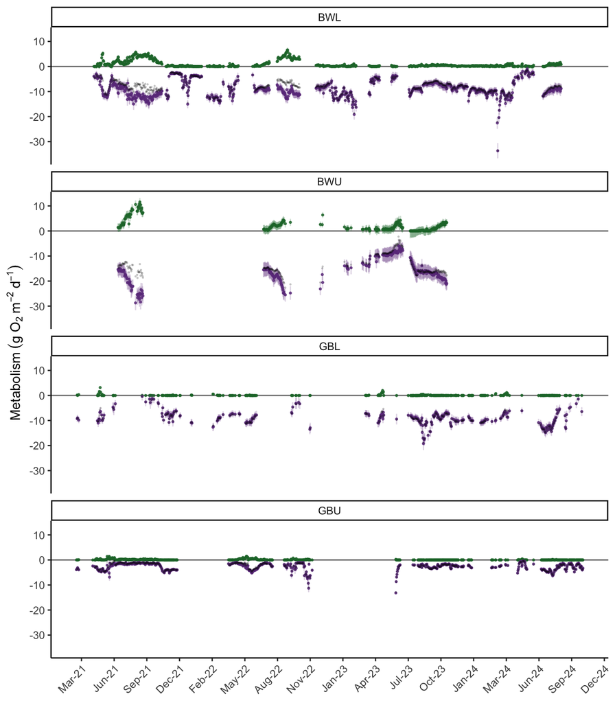

### General drivers of productivity

Each productivity response is individually modeled within stream using `glm`

dataframe = `covariat_datq`

#### A. Biomass models

##### BW:

What’s the response distribution?

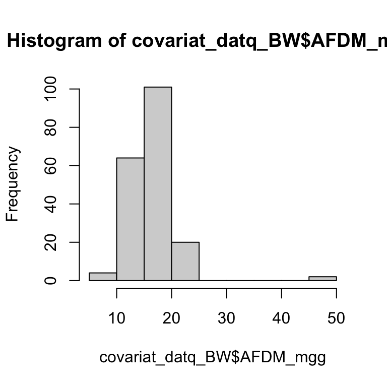

```r
OM_dist <- hist(covariat_datq_BW$AFDM_mgg)
```

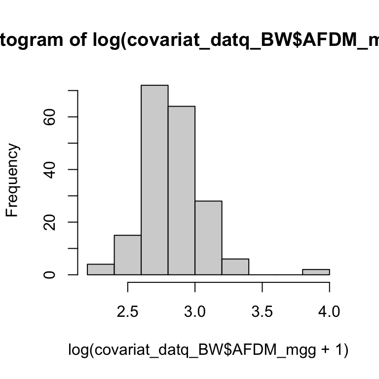

```r
log_OM_dist <- hist(log(covariat_datq_BW$AFDM_mgg+1))
```

Organic matter more normal when log + 1 transformed.

```r
biomass_mod_bw <- glm(log(AFDM_mgg+1)~
                         scale(NO3_mgL_dl* 1000) +
                         scale(NH4_mgL_dl* 1000) +
                         scale(PO4_ugL_dl)+
                         scale(DOC_mgL_dl)+
                         scale(wtr_m) +
                         scale(Q_m), data=covariat_datq_BW)

summary(biomass_mod_bw)
```

```
##
## Call:
## glm(formula = log(AFDM_mgg + 1) ~ scale(NO3_mgL_dl * 1000) +
##     scale(NH4_mgL_dl * 1000) + scale(PO4_ugL_dl) + scale(DOC_mgL_dl) +
##     scale(wtr_m) + scale(Q_m), data = covariat_datq_BW)
##
## Coefficients:
##                           Estimate Std. Error t value Pr(>|t|)
## (Intercept)               2.735605   0.065281  41.905   <2e-16 ***
## scale(NO3_mgL_dl * 1000) -0.154474   0.164053  -0.942   0.3519
## scale(NH4_mgL_dl * 1000)  0.112655   0.064802   1.738   0.0896 .
## scale(PO4_ugL_dl)         0.067648   0.032521   2.080   0.0438 *
## scale(DOC_mgL_dl)        -0.295335   0.129459  -2.281   0.0278 *
## scale(wtr_m)              0.002879   0.040946   0.070   0.9443
## scale(Q_m)                0.016955   0.024716   0.686   0.4966
## ---
## Signif. codes:  0 '***' 0.001 '**' 0.01 '*' 0.05 '.' 0.1 ' ' 1
##
## (Dispersion parameter for gaussian family taken to be 0.03576265)
##
##     Null deviance: 1.8750  on 47  degrees of freedom
## Residual deviance: 1.4663  on 41  degrees of freedom
##   (2744 observations deleted due to missingness)
## AIC: -15.229
##
## Number of Fisher Scoring iterations: 2
```

```r
vif(biomass_mod_bw)
```

```
## scale(NO3_mgL_dl * 1000) scale(NH4_mgL_dl * 1000)        scale(PO4_ugL_dl)
##                 1.184570                 1.623728                 1.104646
##        scale(DOC_mgL_dl)             scale(wtr_m)               scale(Q_m)
##                 1.346611                 1.610071                 1.488666
```

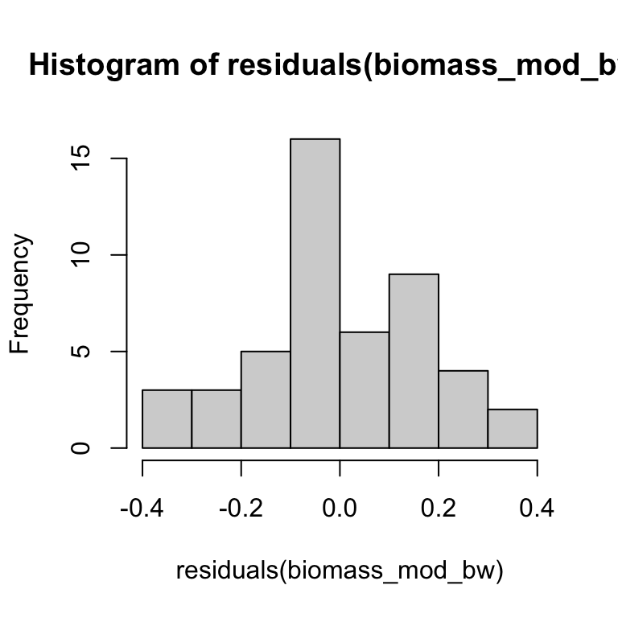

```r
hist(residuals(biomass_mod_bw))
```

```r
r.squaredGLMM(biomass_mod_bw)
```

```
##            R2m       R2c
## [1,] 0.1956202 0.1956202
```

```r
# Extract fixed effects and confidence intervals
fixed_effects <- broom.mixed::tidy(biomass_mod_bw, effects = "fixed", conf.int = TRUE)
# Filter to exclude intercept and arrange predictors
fixed_effects1 <- fixed_effects[fixed_effects$term != "(Intercept)", ]
fixed_effects1 <- fixed_effects1[order(fixed_effects1$estimate), ]  # Order by estimate
fixed_effects1$Catchment <- "BW"
```

##### GB:

What’s the response distribution?

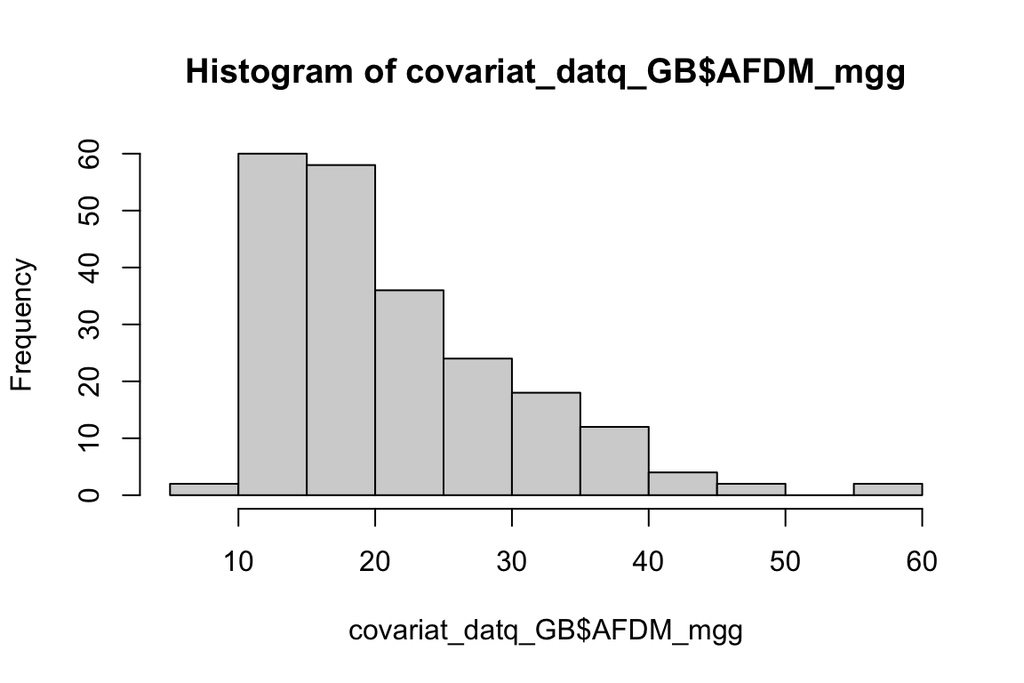

```r
OM_dist <- hist(covariat_datq_GB$AFDM_mgg)
```

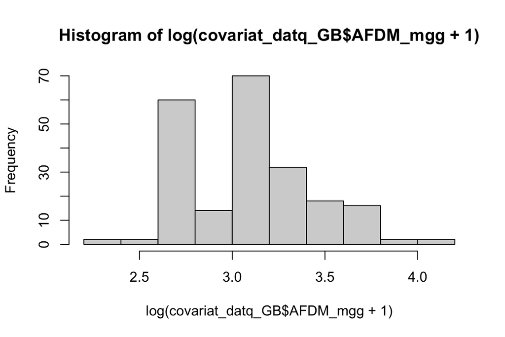

```r
log_OM_dist <- hist(log(covariat_datq_GB$AFDM_mgg+1))
```

```r
biomass_mod_gb <- glm(log(AFDM_mgg+1)~
                         scale(NO3_mgL_dl* 1000) +
                         scale(NH4_mgL_dl* 1000) +
                         scale(PO4_ugL_dl)+
                         scale(DOC_mgL_dl)+
                         scale(wtr_m) +
                         scale(Q_m), data=covariat_datq_GB)

summary(biomass_mod_gb)
```

```
##
## Call:
## glm(formula = log(AFDM_mgg + 1) ~ scale(NO3_mgL_dl * 1000) +
##     scale(NH4_mgL_dl * 1000) + scale(PO4_ugL_dl) + scale(DOC_mgL_dl) +
##     scale(wtr_m) + scale(Q_m), data = covariat_datq_GB)
##
## Coefficients:
##                          Estimate Std. Error t value Pr(>|t|)
## (Intercept)               3.05851    0.15499  19.733   <2e-16 ***
## scale(NO3_mgL_dl * 1000) -0.42980    0.21846  -1.967   0.0556 .
## scale(NH4_mgL_dl * 1000)  0.08945    0.05624   1.591   0.1190
## scale(PO4_ugL_dl)        -0.06077    0.15731  -0.386   0.7012
## scale(DOC_mgL_dl)        -0.10839    0.21978  -0.493   0.6244
## scale(wtr_m)              0.03095    0.06140   0.504   0.6169
## scale(Q_m)               -0.04771    0.04599  -1.038   0.3053
## ---
## Signif. codes:  0 '***' 0.001 '**' 0.01 '*' 0.05 '.' 0.1 ' ' 1
##
## (Dispersion parameter for gaussian family taken to be 0.1215764)
##
##     Null deviance: 6.2535  on 49  degrees of freedom
## Residual deviance: 5.2278  on 43  degrees of freedom
##   (2755 observations deleted due to missingness)
## AIC: 44.992
##
## Number of Fisher Scoring iterations: 2
```

```r
vif(biomass_mod_gb)
```

```
## scale(NO3_mgL_dl * 1000) scale(NH4_mgL_dl * 1000)        scale(PO4_ugL_dl)
##                 1.581656                 2.190022                 2.152824
##        scale(DOC_mgL_dl)             scale(wtr_m)               scale(Q_m)
##                 1.999064                 1.308953                 2.016183
```

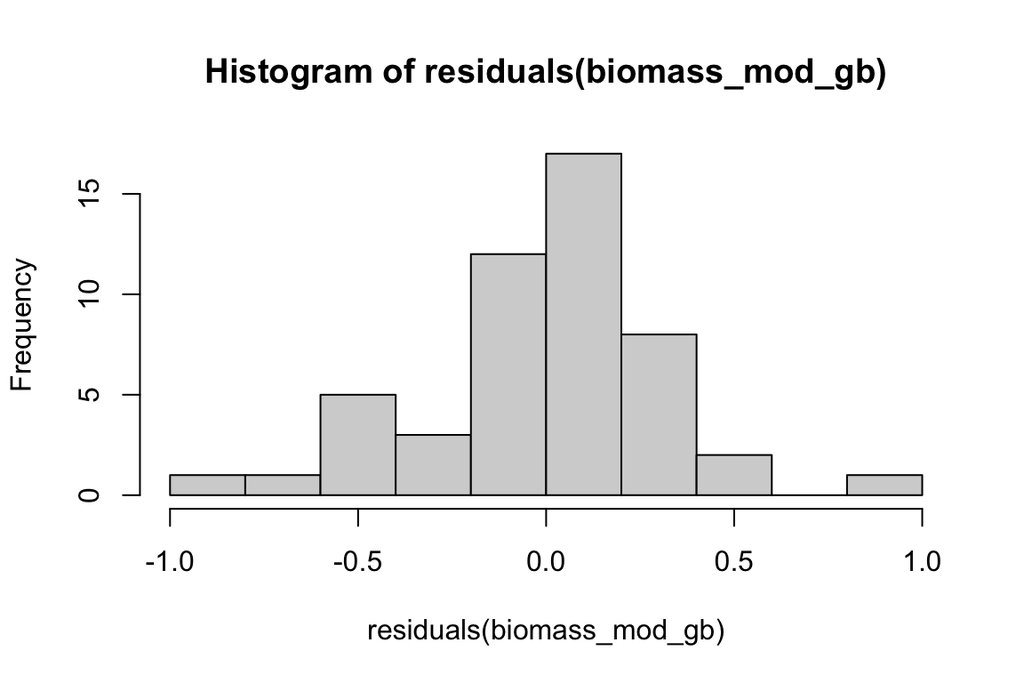

```r
hist(residuals(biomass_mod_gb))
```

```r
r.squaredGLMM(biomass_mod_gb)
```

```
##            R2m       R2c
## [1,] 0.1468824 0.1468824
```

```r
fixed_effects_gb <- broom.mixed::tidy(biomass_mod_gb, effects = "fixed", conf.int = TRUE)

# Filter to exclude intercept and arrange predictors
fixed_effects_gb1 <- fixed_effects_gb[fixed_effects_gb$term != "(Intercept)", ]
fixed_effects_gb1 <- fixed_effects_gb1[order(fixed_effects_gb1$estimate), ]  # Order by estimate
fixed_effects_gb1$Catchment <- "GB"
```

#### B. Chlorophyll-a models

##### BW:

What’s the response distribution?

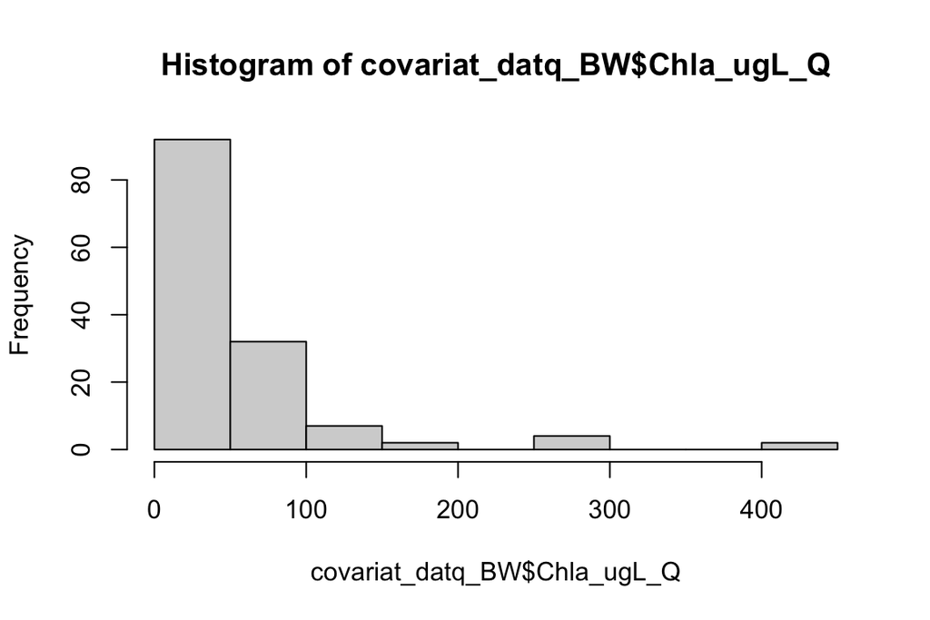

```r
chla_dist <- hist(covariat_datq_BW$Chla_ugL_Q)
```

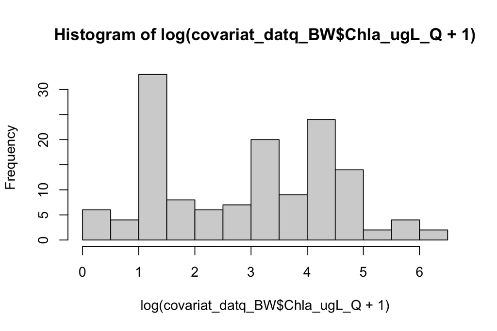

```r
chla_OM_dist <- hist(log(covariat_datq_BW$Chla_ugL_Q+1))
```

```r
chla_mod_bw <- glm(log(Chla_ugL_Q+1)~
                         scale(NO3_mgL_dl* 1000) +
                         scale(NH4_mgL_dl* 1000) +
                         scale(PO4_ugL_dl)+
                         scale(DOC_mgL_dl)+
                         scale(wtr_m) +
                         scale(Q_m), data=covariat_datq_BW)

summary(chla_mod_bw)
```

```
##
## Call:
## glm(formula = log(Chla_ugL_Q + 1) ~ scale(NO3_mgL_dl * 1000) +
##     scale(NH4_mgL_dl * 1000) + scale(PO4_ugL_dl) + scale(DOC_mgL_dl) +
##     scale(wtr_m) + scale(Q_m), data = covariat_datq_BW)
##
## Coefficients:
##                          Estimate Std. Error t value Pr(>|t|)
## (Intercept)                3.5284     0.7801   4.523 0.000102 ***
## scale(NO3_mgL_dl * 1000)   1.0001     2.3113   0.433 0.668554
## scale(NH4_mgL_dl * 1000)   0.6151     0.6538   0.941 0.354848
## scale(PO4_ugL_dl)          0.4778     0.3136   1.523 0.138867
## scale(DOC_mgL_dl)         -0.2148     0.8708  -0.247 0.806938
## scale(wtr_m)               0.1590     0.3840   0.414 0.681884
## scale(Q_m)                 0.0959     0.2328   0.412 0.683467
## ---
## Signif. codes:  0 '***' 0.001 '**' 0.01 '*' 0.05 '.' 0.1 ' ' 1
##
## (Dispersion parameter for gaussian family taken to be 2.835128)
##
##     Null deviance: 96.278  on 34  degrees of freedom
## Residual deviance: 79.384  on 28  degrees of freedom
##   (2757 observations deleted due to missingness)
## AIC: 143.99
##
## Number of Fisher Scoring iterations: 2
```

```r
vif(chla_mod_bw)
```

```
## scale(NO3_mgL_dl * 1000) scale(NH4_mgL_dl * 1000)        scale(PO4_ugL_dl)
##                 2.015540                 1.761005                 1.247534
##        scale(DOC_mgL_dl)             scale(wtr_m)               scale(Q_m)
##                 1.432750                 1.660374                 1.528661
```

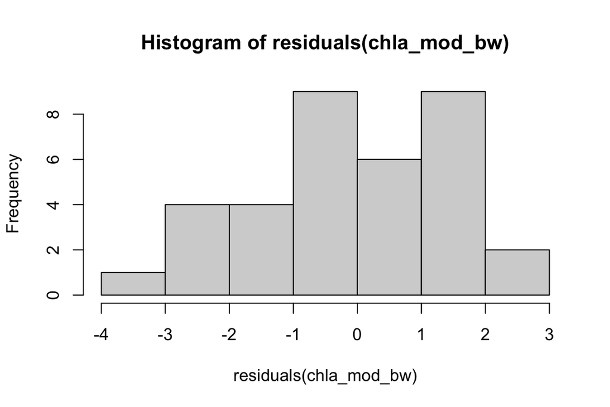

```r
hist(residuals(chla_mod_bw))
```

```r
r.squaredGLMM(chla_mod_bw)
```

```
##           R2m      R2c
## [1,] 0.149126 0.149126
```

```r
# Extract fixed effects and confidence intervals
fixed_effects_chl <- broom.mixed::tidy(chla_mod_bw, effects = "fixed", conf.int = TRUE)
# Filter to exclude intercept and arrange predictors
fixed_effects_chl1 <- fixed_effects_chl[fixed_effects_chl$term != "(Intercept)", ]
fixed_effects_chl1 <- fixed_effects_chl1[order(fixed_effects_chl1$estimate), ]  # Order by estimate
fixed_effects_chl1$Catchment <- "BW"
```

##### GB:

What’s the response distribution?

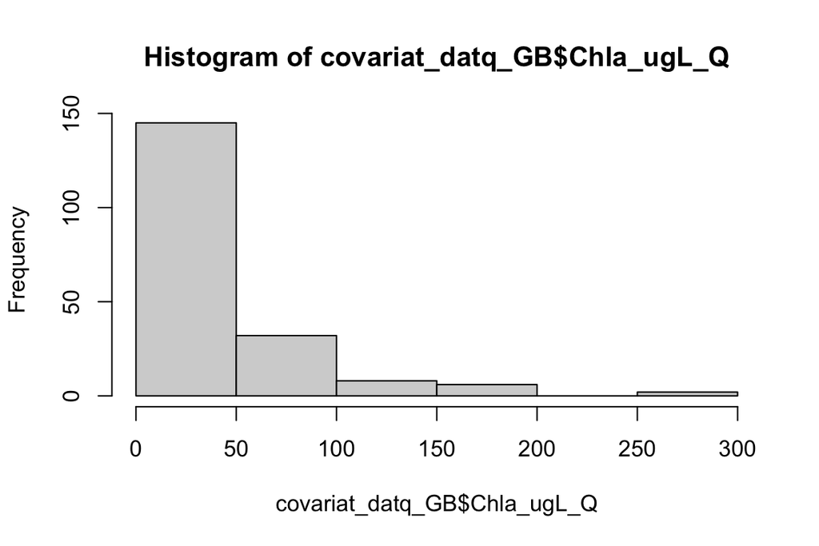

```r
chla_dist <- hist(covariat_datq_GB$Chla_ugL_Q)
```

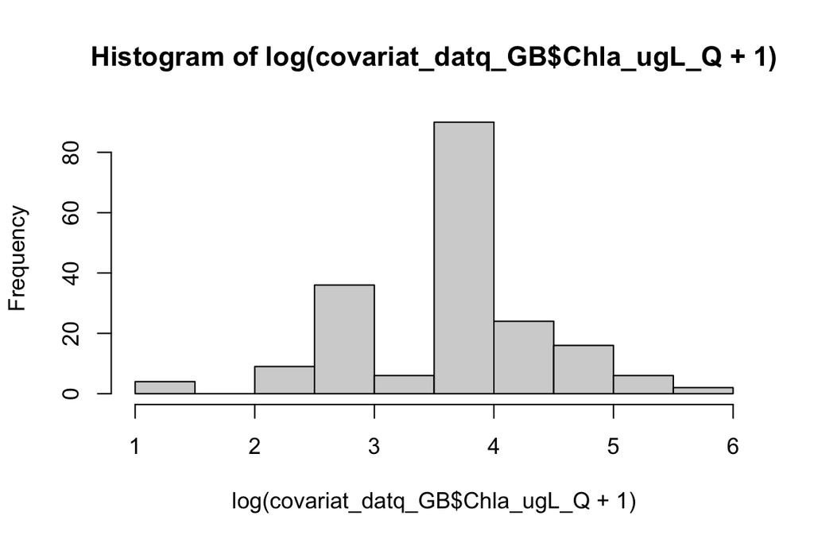

```r
chla_OM_dist <- hist(log(covariat_datq_GB$Chla_ugL_Q+1))
```

```r
chla_mod_gb <- glm(log(Chla_ugL_Q+1)~
                      scale(NO3_mgL_dl* 1000) +
                      scale(NH4_mgL_dl* 1000) +
                      scale(PO4_ugL_dl)+
                      scale(DOC_mgL_dl)+
                      scale(wtr_m) +
                      scale(Q_m), data=covariat_datq_GB)

summary(chla_mod_gb)
```

```
##
## Call:
## glm(formula = log(Chla_ugL_Q + 1) ~ scale(NO3_mgL_dl * 1000) +
##     scale(NH4_mgL_dl * 1000) + scale(PO4_ugL_dl) + scale(DOC_mgL_dl) +
##     scale(wtr_m) + scale(Q_m), data = covariat_datq_GB)
##
## Coefficients:
##                          Estimate Std. Error t value Pr(>|t|)
## (Intercept)               3.28194    0.33158   9.898 5.81e-11 ***
## scale(NO3_mgL_dl * 1000) -3.52823    1.01520  -3.475  0.00158 **
## scale(NH4_mgL_dl * 1000)  0.73929    0.56429   1.310  0.20010
## scale(PO4_ugL_dl)         1.03719    0.58939   1.760  0.08864 .
## scale(DOC_mgL_dl)        -0.01634    0.14095  -0.116  0.90847
## scale(wtr_m)              0.26286    0.17019   1.544  0.13296
## scale(Q_m)               -0.11862    0.16474  -0.720  0.47708
## ---
## Signif. codes:  0 '***' 0.001 '**' 0.01 '*' 0.05 '.' 0.1 ' ' 1
##
## (Dispersion parameter for gaussian family taken to be 0.724672)
##
##     Null deviance: 40.957  on 36  degrees of freedom
## Residual deviance: 21.740  on 30  degrees of freedom
##   (2768 observations deleted due to missingness)
## AIC: 101.33
##
## Number of Fisher Scoring iterations: 2
```

```r
vif(chla_mod_gb)
```

```
## scale(NO3_mgL_dl * 1000) scale(NH4_mgL_dl * 1000)        scale(PO4_ugL_dl)
##                 1.512451                 1.958133                 2.579540
##        scale(DOC_mgL_dl)             scale(wtr_m)               scale(Q_m)
##                 1.452931                 1.380456                 2.628932
```

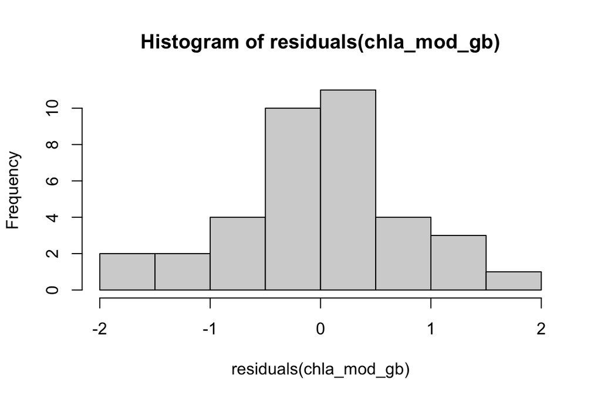

```r
hist(residuals(chla_mod_gb))
```

```r
r.squaredGLMM(chla_mod_gb)
```

```
##            R2m       R2c
## [1,] 0.4241605 0.4241605
```

```r
fixed_effects_chlg <- broom.mixed::tidy(chla_mod_gb, effects = "fixed", conf.int = TRUE)
# Filter to exclude intercept and arrange predictors
fixed_effects_chlg1 <- fixed_effects_chlg[fixed_effects_chlg$term != "(Intercept)", ]
fixed_effects_chlg1 <- fixed_effects_chlg1[order(fixed_effects_chlg1$estimate), ]  # Order by estimate
fixed_effects_chlg1$Catchment <- "GB"
```

#### C. GPP models

What’s the response distribution?

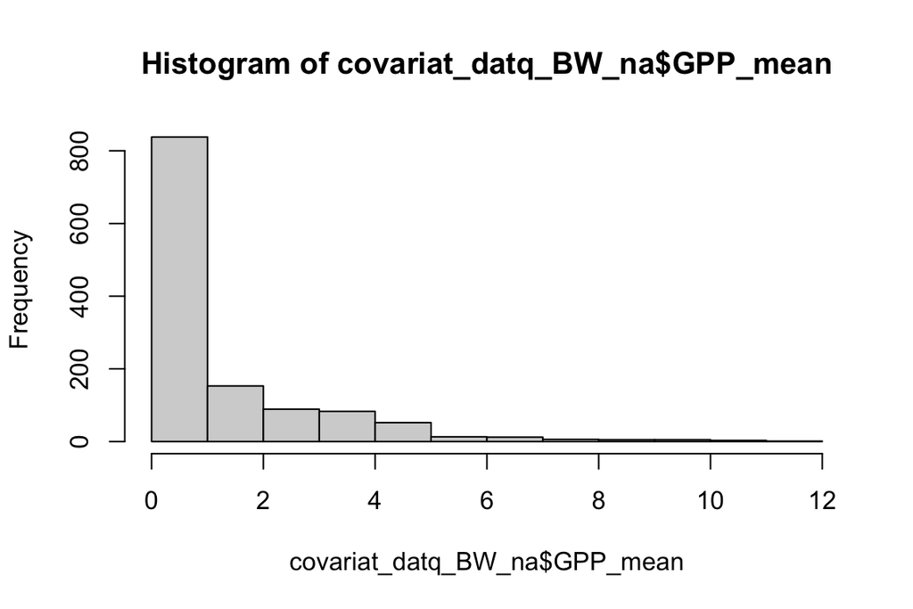

```r
covariat_datq_BW_na <- covariat_datq_BW %>%
  drop_na(GPP_mean)

GPP_dist <- hist(covariat_datq_BW_na$GPP_mean)
```

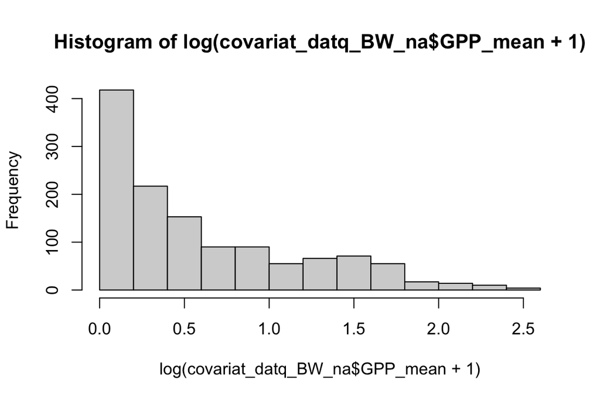

```r
GPP_OM_dist <- hist(log(covariat_datq_BW_na$GPP_mean+1))
```

Possibility still too skewed to use a normal distribution in lmer.

```r
gpp_mod_bw <- glm(log(GPP_mean+1)~
                      scale(NO3_mgL_dl* 1000) +
                      scale(NH4_mgL_dl* 1000) +
                      scale(PO4_ugL_dl)+
                      scale(DOC_mgL_dl)+
                      scale(wtr_m) +
                      scale(Q_m), data=covariat_datq_BW_na)

summary(gpp_mod_bw)
```

```
##
## Call:
## glm(formula = log(GPP_mean + 1) ~ scale(NO3_mgL_dl * 1000) +
##     scale(NH4_mgL_dl * 1000) + scale(PO4_ugL_dl) + scale(DOC_mgL_dl) +
##     scale(wtr_m) + scale(Q_m), data = covariat_datq_BW_na)
##
## Coefficients:
##                            Estimate Std. Error t value Pr(>|t|)
## (Intercept)               0.7344099  0.2140363   3.431  0.00177 **
## scale(NO3_mgL_dl * 1000)  0.6212286  0.4975191   1.249  0.22145
## scale(NH4_mgL_dl * 1000)  0.1491176  0.0945384   1.577  0.12521
## scale(PO4_ugL_dl)        -0.1372775  0.1073621  -1.279  0.21083
## scale(DOC_mgL_dl)         0.2848190  0.1009365   2.822  0.00839 **
## scale(wtr_m)              0.1822010  0.0848921   2.146  0.04006 *
## scale(Q_m)               -0.0006826  0.0545601  -0.013  0.99010
## ---
## Signif. codes:  0 '***' 0.001 '**' 0.01 '*' 0.05 '.' 0.1 ' ' 1
##
## (Dispersion parameter for gaussian family taken to be 0.180498)
##
##     Null deviance: 9.8501  on 36  degrees of freedom
## Residual deviance: 5.4149  on 30  degrees of freedom
##   (1223 observations deleted due to missingness)
## AIC: 49.896
##
## Number of Fisher Scoring iterations: 2
```

```r
vif(gpp_mod_bw)
```

```
## scale(NO3_mgL_dl * 1000) scale(NH4_mgL_dl * 1000)        scale(PO4_ugL_dl)
##                 1.333081                 1.147816                 1.030812
##        scale(DOC_mgL_dl)             scale(wtr_m)               scale(Q_m)
##                 1.663285                 1.431078                 1.285193
```

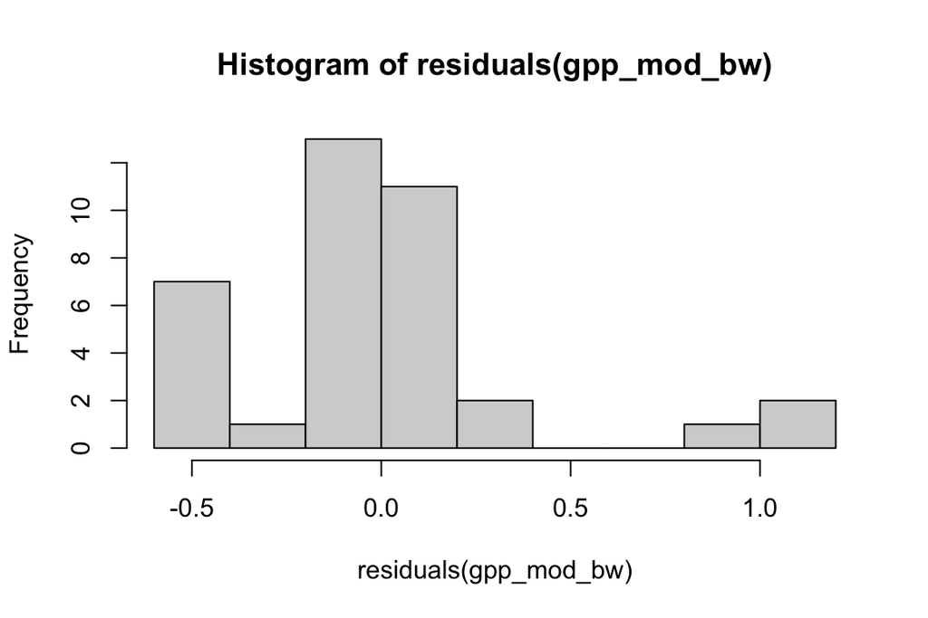

```r
hist(residuals(gpp_mod_bw))
```

```r
r.squaredGLMM(gpp_mod_bw)
```

```
##            R2m       R2c
## [1,] 0.4056616 0.4056616
```

```r
# Extract fixed effects and confidence intervals
fixed_effects_nep <- broom.mixed::tidy(gpp_mod_bw, effects = "fixed", conf.int = TRUE)
# Filter to exclude intercept and arrange predictors
fixed_effects_nep <- fixed_effects_nep[fixed_effects_nep$term != "(Intercept)", ]
fixed_effects_nep <- fixed_effects_nep[order(fixed_effects_nep$estimate), ]  # Order by estimate
fixed_effects_nep$Catchment <- "BW"
```

##### GB:

What’s the response distribution?

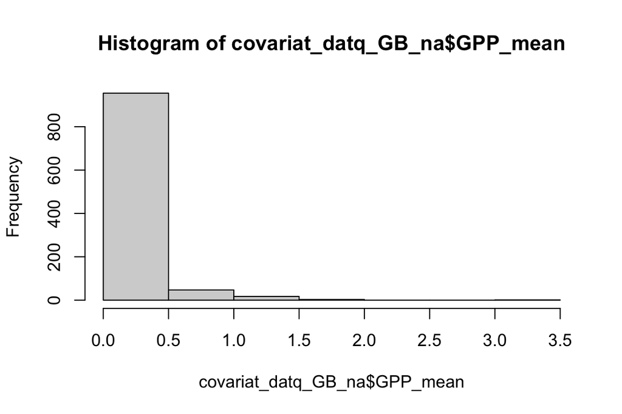

```r
covariat_datq_GB_na <- covariat_datq_GB %>%
    drop_na(GPP_mean)

  #drop_na(GPP_mean)

GPP_dist <- hist(covariat_datq_GB_na$GPP_mean)
```

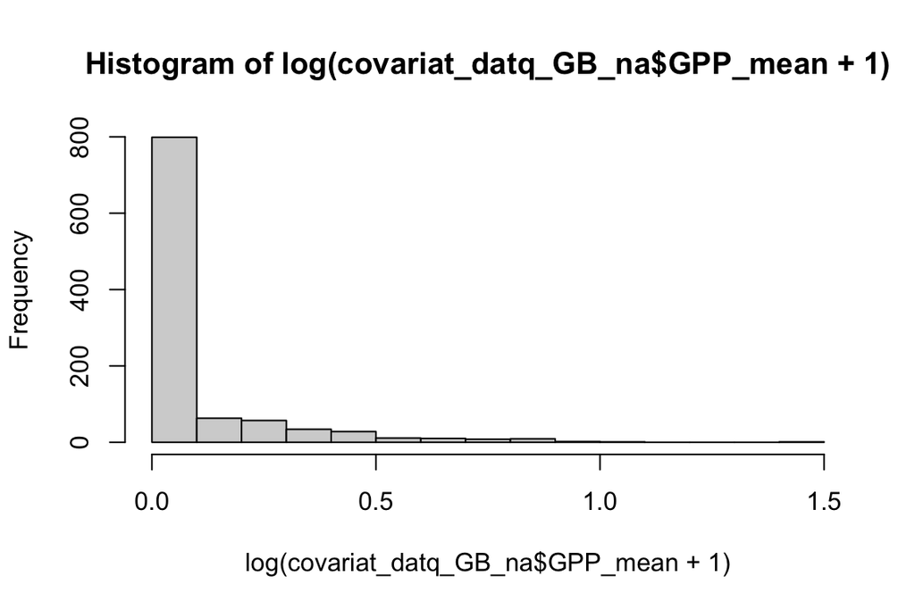

```r
GPP_OM_dist <- hist(log(covariat_datq_GB_na$GPP_mean+1))
```

Highly skewed even when log transformed.

```r
gpp_mod_gb <- lm(log(GPP_mean+1) ~
                      scale(NO3_mgL_dl* 1000) +
                      scale(NH4_mgL_dl* 1000) +
                      scale(PO4_ugL_dl)+
                      scale(DOC_mgL_dl)+
                      scale(wtr_m) +
                      scale(Q_m), data=covariat_datq_GB_na)

summary(gpp_mod_gb)
```

```
##
## Call:
## lm(formula = log(GPP_mean + 1) ~ scale(NO3_mgL_dl * 1000) + scale(NH4_mgL_dl *
##     1000) + scale(PO4_ugL_dl) + scale(DOC_mgL_dl) + scale(wtr_m) +
##     scale(Q_m), data = covariat_datq_GB_na)
##
## Residuals:
##      Min       1Q   Median       3Q      Max
## -0.14035 -0.03979 -0.00806  0.01972  0.27154
##
## Coefficients:
##                          Estimate Std. Error t value Pr(>|t|)
## (Intercept)               0.14759    0.11712   1.260    0.234
## scale(NO3_mgL_dl * 1000) -0.08651    0.15916  -0.544    0.598
## scale(NH4_mgL_dl * 1000)  0.23631    0.16188   1.460    0.172
## scale(PO4_ugL_dl)         0.02920    0.06532   0.447    0.663
## scale(DOC_mgL_dl)        -0.03322    0.02825  -1.176    0.264
## scale(wtr_m)             -0.01274    0.04696  -0.271    0.791
## scale(Q_m)               -0.05798    0.05891  -0.984    0.346
##
## Residual standard error: 0.1091 on 11 degrees of freedom
##   (1005 observations deleted due to missingness)
## Multiple R-squared:  0.3593, Adjusted R-squared:  0.00988
## F-statistic: 1.028 on 6 and 11 DF,  p-value: 0.4565
```

```r
vif(gpp_mod_gb)
```

```
## scale(NO3_mgL_dl * 1000) scale(NH4_mgL_dl * 1000)        scale(PO4_ugL_dl)
##                 1.376245                 1.226297                 1.631468
##        scale(DOC_mgL_dl)             scale(wtr_m)               scale(Q_m)
##                 1.789801                 2.190438                 1.764154
```

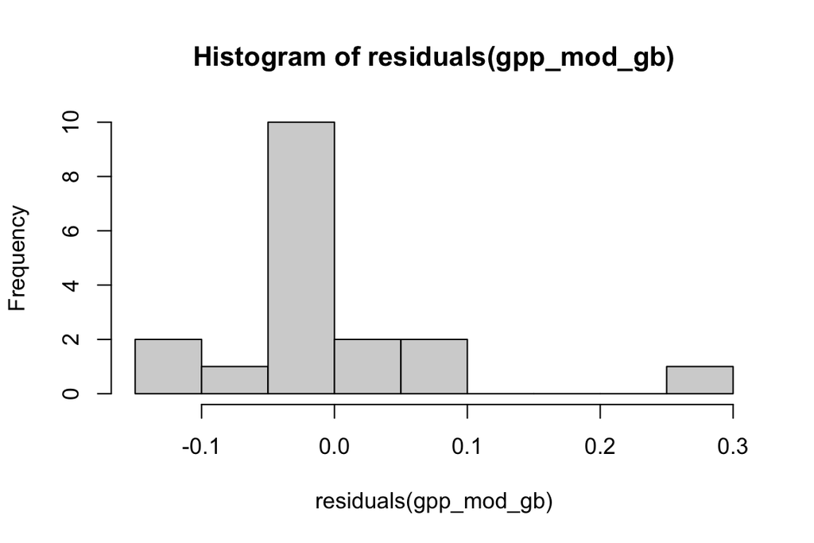

```r
hist(residuals(gpp_mod_gb))
```

```r
r.squaredGLMM(gpp_mod_gb)
```

```
##            R2m       R2c
## [1,] 0.2662809 0.2662809
```

```r
fixed_effects_nep1 <- broom.mixed::tidy(gpp_mod_gb, effects = "fixed", conf.int = TRUE)
# Filter to exclude intercept and arrange predictors
fixed_effects_nep1 <- fixed_effects_nep1[fixed_effects_nep1$term != "(Intercept)", ]
fixed_effects_nep1 <- fixed_effects_nep1[order(fixed_effects_nep1$estimate), ]  # Order by estimate
fixed_effects_nep1$Catchment <- "GB"
```

### Figures 3: General drivers for biomass, chl-a and GPP

Mainly addresses how productivity is associated with nutrients and water qualilty:

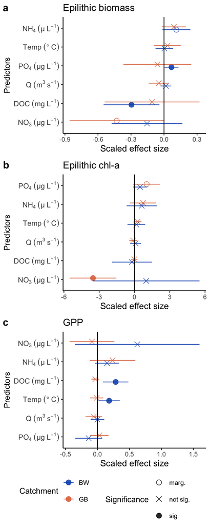

## Question 2:

2. Is variance in nitrogen uptake (either as ammonium or nitrate) more related to biological (GPP, ER, biomass or chl-a), physical processes (flow and water temperature), or ambient nutrient and organic matter supplies?

### Figure 4: N uptake variation by N species and reach location

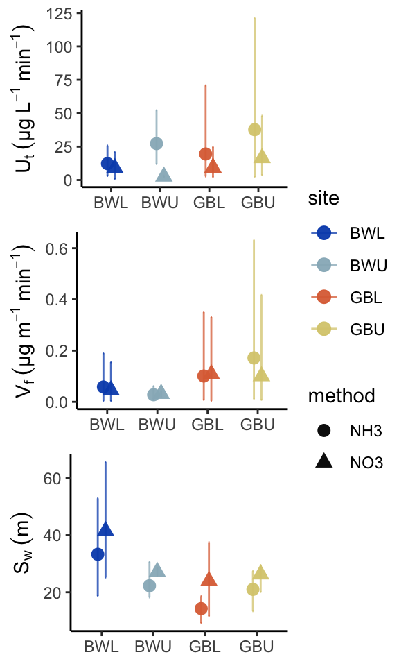

### Figure 5/ (maybe 4b?): N uptake correlation between (GPP, ER, biomass or chl-a) or Q and temp

Color by site, Shape by N uptake method

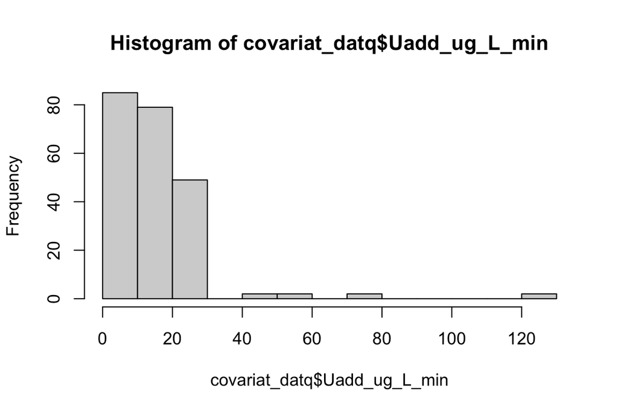

```r
hist(covariat_datq$Uadd_ug_L_min)
```

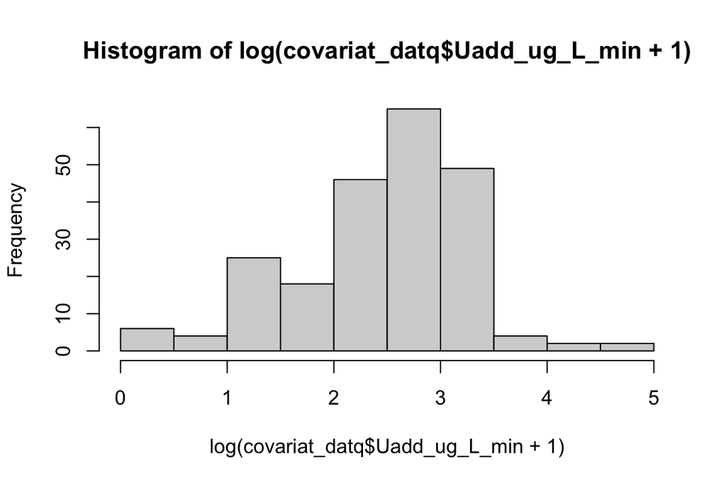

```r
hist(log(covariat_datq$Uadd_ug_L_min+1))
```

```r
U_mod_bio <- lmer(log(Uadd_ug_L_min+1) ~
                      scale(AFDM_mgcm2) + (1|site), data=covariat_datq)
summary(U_mod_bio)
```

```
## Linear mixed model fit by REML. t-tests use Satterthwaite's method [
## lmerModLmerTest]
## Formula: log(Uadd_ug_L_min + 1) ~ scale(AFDM_mgcm2) + (1 | site)
##    Data: covariat_datq
##
## REML criterion at convergence: 256.9
##
## Scaled residuals:
##     Min      1Q  Median      3Q     Max
## -2.1978 -0.6073  0.1454  0.5227  2.1775
##
## Random effects:
##  Groups   Name        Variance Std.Dev.
##  site     (Intercept) 0.1869   0.4323
##  Residual             0.8292   0.9106
## Number of obs: 94, groups:  site, 4
##
## Fixed effects:
##                   Estimate Std. Error      df t value Pr(>|t|)
## (Intercept)         2.4985     0.2466  2.0570  10.134  0.00873 **
## scale(AFDM_mgcm2)  -0.2824     0.1439 90.0657  -1.963  0.05271 .
## ---
## Signif. codes:  0 '***' 0.001 '**' 0.01 '*' 0.05 '.' 0.1 ' ' 1
##
## Correlation of Fixed Effects:
##             (Intr)
## scl(AFDM_2) 0.056
```

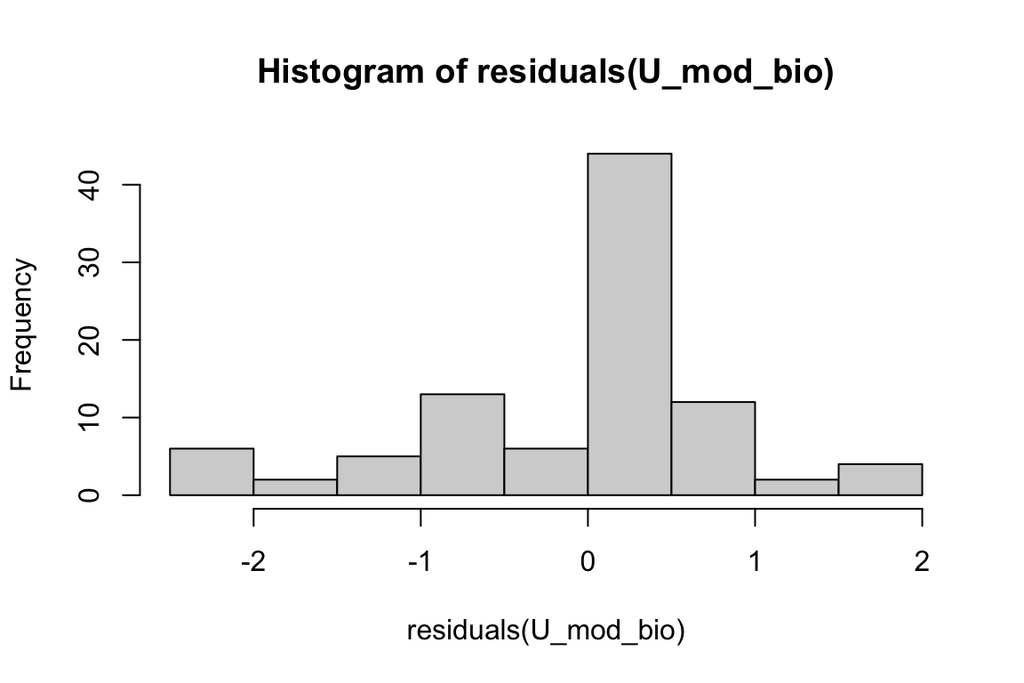

```r
hist(residuals(U_mod_bio))
```

```r
U_mod_bio_r2_vals <- r.squaredGLMM(U_mod_bio)
U_mod_bio_conditional_r2 <- round(U_mod_bio_r2_vals[2], 2)
```

```r
U_mod_chla <- lmer(log(Uadd_ug_L_min+1) ~
                      scale(Chla_ugL_Q) + (1|site), data=covariat_datq)

summary(U_mod_chla)
```

```
## Linear mixed model fit by REML. t-tests use Satterthwaite's method [
## lmerModLmerTest]
## Formula: log(Uadd_ug_L_min + 1) ~ scale(Chla_ugL_Q) + (1 | site)
##    Data: covariat_datq
##
## REML criterion at convergence: 304.7
##
## Scaled residuals:
##     Min      1Q  Median      3Q     Max
## -3.2244 -0.0396  0.0880  0.5079  2.7930
##
## Random effects:
##  Groups   Name        Variance Std.Dev.
##  site     (Intercept) 0.1124   0.3352
##  Residual             0.4370   0.6611
## Number of obs: 146, groups:  site, 4
##
## Fixed effects:
##                    Estimate Std. Error        df t value Pr(>|t|)
## (Intercept)         2.58145    0.18362   3.35559   14.06 0.000424 ***
## scale(Chla_ugL_Q)  -0.36423    0.08241 143.90623   -4.42 1.93e-05 ***
## ---
## Signif. codes:  0 '***' 0.001 '**' 0.01 '*' 0.05 '.' 0.1 ' ' 1
##
## Correlation of Fixed Effects:
##             (Intr)
## scl(Ch_L_Q) 0.084
```

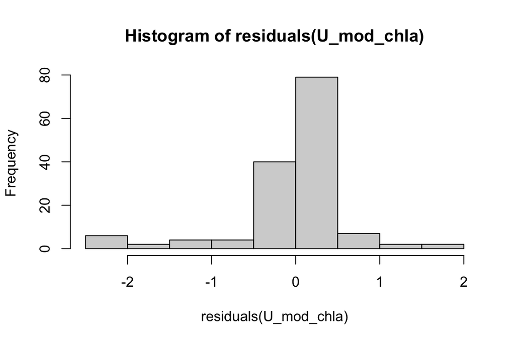

```r
hist(residuals(U_mod_chla))
```

```r
r.squaredGLMM(U_mod_chla)
```

```
##            R2m       R2c
## [1,] 0.1018065 0.2855367
```

```r
U_mod_chla_r2_vals <- r.squaredGLMM(U_mod_chla)
U_mod_chla_conditional_r2 <- round(U_mod_chla_r2_vals[2], 2)
```

```r
U_mod_GPP <- lmer(log(Uadd_ug_L_min+1) ~
                      scale(GPP_mean) + (1|site), data=covariat_datq)

summary(U_mod_GPP)
```

```
## Linear mixed model fit by REML. t-tests use Satterthwaite's method [
## lmerModLmerTest]
## Formula: log(Uadd_ug_L_min + 1) ~ scale(GPP_mean) + (1 | site)
##    Data: covariat_datq
##
## REML criterion at convergence: 208.7
##
## Scaled residuals:
##     Min      1Q  Median      3Q     Max
## -2.1714 -0.5792  0.0048  0.3286  2.7491
##
## Random effects:
##  Groups   Name        Variance Std.Dev.
##  site     (Intercept) 0.1814   0.4259
##  Residual             0.5360   0.7321
## Number of obs: 90, groups:  site, 4
##
## Fixed effects:
##                 Estimate Std. Error       df t value Pr(>|t|)
## (Intercept)      2.26532    0.23018  2.48473   9.841  0.00473 **
## scale(GPP_mean) -0.05922    0.14806 86.98125  -0.400  0.69014
## ---
## Signif. codes:  0 '***' 0.001 '**' 0.01 '*' 0.05 '.' 0.1 ' ' 1
##
## Correlation of Fixed Effects:
##             (Intr)
## scl(GPP_mn) 0.058
```

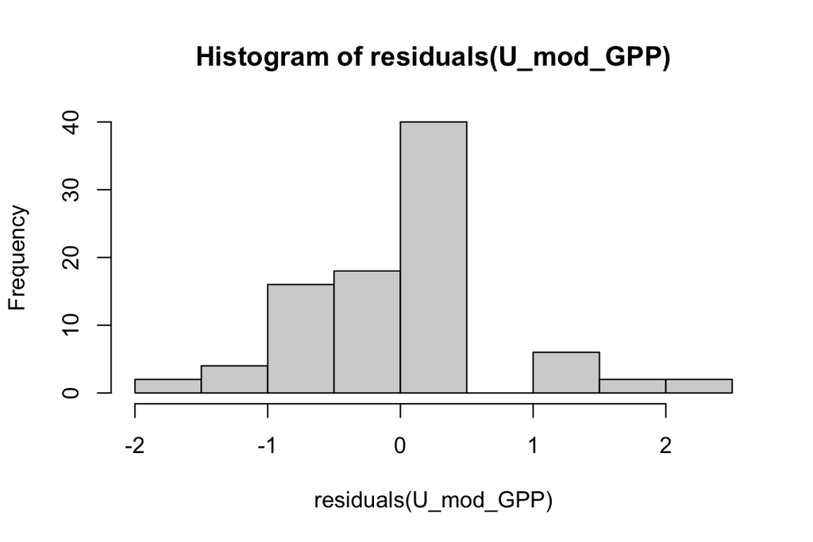

```r
hist(residuals(U_mod_GPP))
```

```r
U_mod_GPP_r2_vals <- r.squaredGLMM(U_mod_GPP)
U_mod_GPP_conditional_r2 <- round(U_mod_GPP_r2_vals[2], 2)
```

```r
U_mod_ER <- lmer(log(Uadd_ug_L_min+1) ~
                      scale((ER_mean*-1)) + (1|site), data=covariat_datq)

summary(U_mod_ER)
```

```
## Linear mixed model fit by REML. t-tests use Satterthwaite's method [
## lmerModLmerTest]
## Formula: log(Uadd_ug_L_min + 1) ~ scale((ER_mean * -1)) + (1 | site)
##    Data: covariat_datq
##
## REML criterion at convergence: 180.1
##
## Scaled residuals:
##      Min       1Q   Median       3Q      Max
## -2.60233 -0.51275  0.07987  0.69374  2.15588
##
## Random effects:
##  Groups   Name        Variance Std.Dev.
##  site     (Intercept) 1.0894   1.0438
##  Residual             0.3641   0.6034
## Number of obs: 90, groups:  site, 4
##
## Fixed effects:
##                       Estimate Std. Error      df t value Pr(>|t|)
## (Intercept)             1.8197     0.5328  2.8567   3.416   0.0452 *
## scale((ER_mean * -1))   1.0520     0.1717 86.8905   6.126 2.55e-08 ***
## ---
## Signif. codes:  0 '***' 0.001 '**' 0.01 '*' 0.05 '.' 0.1 ' ' 1
##
## Correlation of Fixed Effects:
##             (Intr)
## s((ER_*-1)) -0.147
```

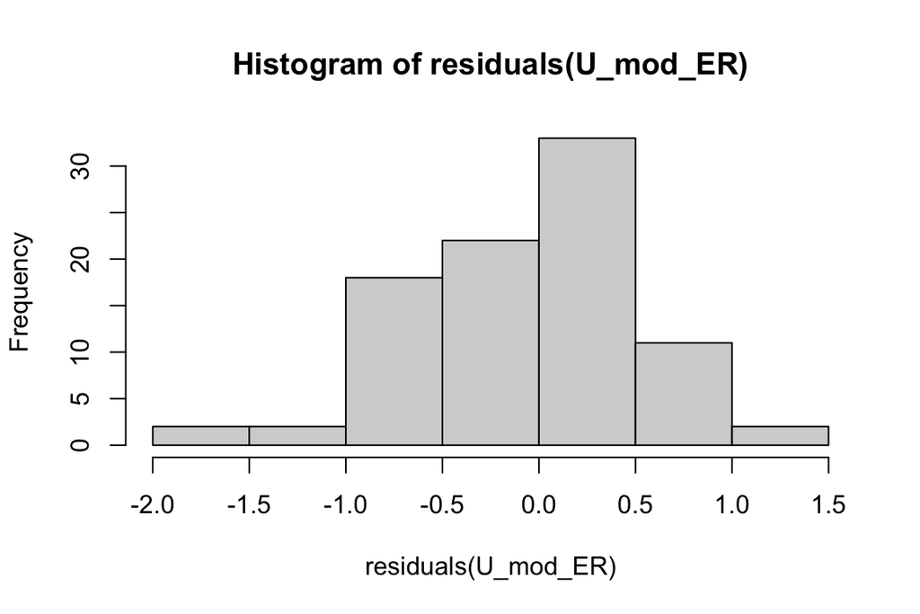

```r
hist(residuals(U_mod_ER))
```

```r
U_mod_ER_r2_vals <- r.squaredGLMM(U_mod_ER)
U_mod_ER_conditional_r2 <- round(U_mod_ER_r2_vals[2], 2)
```

```r
U_mod_Q <- lmer(log(Uadd_ug_L_min+1) ~
                      scale((Q_m)) + (1|site), data=covariat_datq)

summary(U_mod_Q)
```

```
## Linear mixed model fit by REML. t-tests use Satterthwaite's method [
## lmerModLmerTest]
## Formula: log(Uadd_ug_L_min + 1) ~ scale((Q_m)) + (1 | site)
##    Data: covariat_datq
##
## REML criterion at convergence: 444.2
##
## Scaled residuals:
##      Min       1Q   Median       3Q      Max
## -2.91606 -0.33220  0.07259  0.46584  2.69714
##
## Random effects:
##  Groups   Name        Variance Std.Dev.
##  site     (Intercept) 0.2515   0.5014
##  Residual             0.4502   0.6710
## Number of obs: 211, groups:  site, 4
##
## Fixed effects:
##              Estimate Std. Error       df t value Pr(>|t|)
## (Intercept)    2.7557     0.2597   3.2239  10.612  0.00129 **
## scale((Q_m))   1.5145     0.1960 208.6859   7.727 4.55e-13 ***
## ---
## Signif. codes:  0 '***' 0.001 '**' 0.01 '*' 0.05 '.' 0.1 ' ' 1
##
## Correlation of Fixed Effects:
##             (Intr)
## scal((Q_m)) 0.182
```

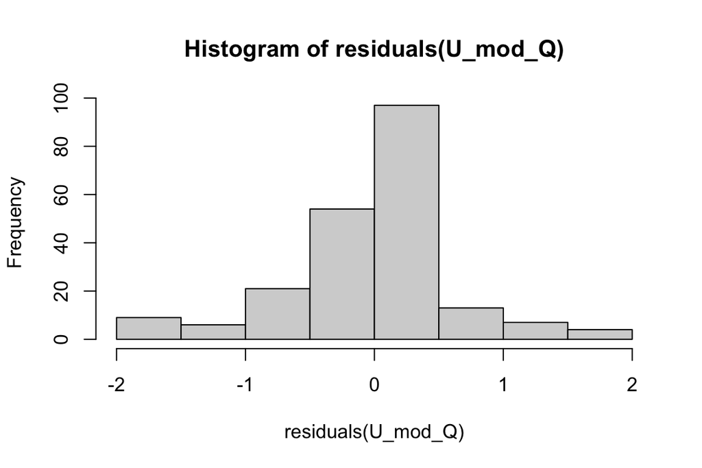

```r
hist(residuals(U_mod_Q))
```

```r
U_mod_Q_r2_vals <- r.squaredGLMM(U_mod_Q)
U_mod_Q_conditional_r2 <- round(U_mod_Q_r2_vals[2], 2)
```

```r
U_mod_temp <- lmer(log(Uadd_ug_L_min+1) ~
                      scale(wtr_m) + (1|site), data=covariat_datq)

summary(U_mod_temp)
```

```
## Linear mixed model fit by REML. t-tests use Satterthwaite's method [
## lmerModLmerTest]
## Formula: log(Uadd_ug_L_min + 1) ~ scale(wtr_m) + (1 | site)
##    Data: covariat_datq
##
## REML criterion at convergence: 497.4
##
## Scaled residuals:
##      Min       1Q   Median       3Q      Max
## -2.69400 -0.38952  0.05007  0.43028  2.73501
##
## Random effects:
##  Groups   Name        Variance Std.Dev.
##  site     (Intercept) 0.1604   0.4005
##  Residual             0.5807   0.7620
## Number of obs: 211, groups:  site, 4
##
## Fixed effects:
##               Estimate Std. Error        df t value Pr(>|t|)
## (Intercept)    2.43008    0.21229   3.37472  11.447 0.000812 ***
## scale(wtr_m)  -0.07011    0.08279 206.95515  -0.847 0.398030
## ---
## Signif. codes:  0 '***' 0.001 '**' 0.01 '*' 0.05 '.' 0.1 ' ' 1
##
## Correlation of Fixed Effects:
##             (Intr)
## scal(wtr_m) -0.209
```

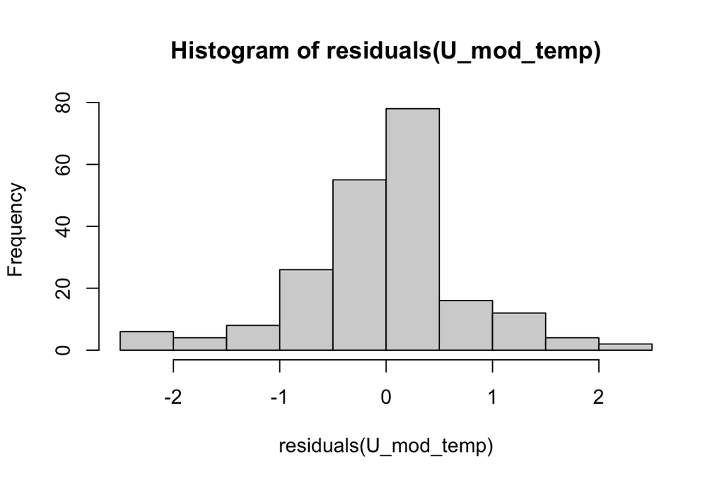

```r
hist(residuals(U_mod_temp))
```

```r
r.squaredGLMM(U_mod_temp)
```

```
##             R2m       R2c
## [1,] 0.00277555 0.2186063
```

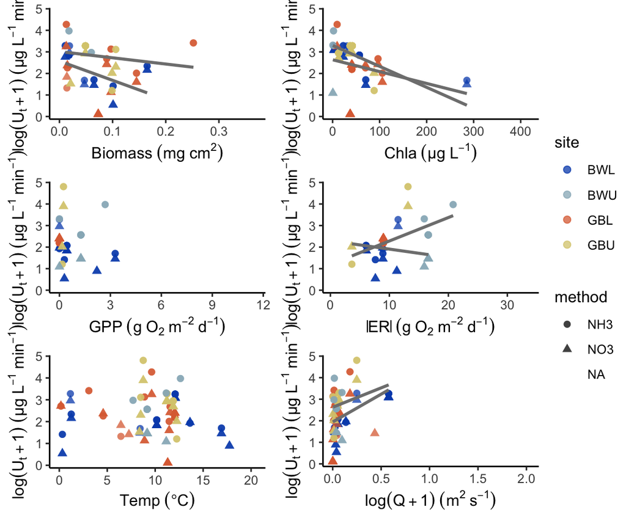